# 20180815_WorMotel_Heritability_subsampling

Tim C.

8/15/2018

This code uses processed survival data from Chris Fang-Yen’s lab to calculate heritability of survival traits. The data were collected with WorMotel in four replicate blocks (independent bleaches) by Matt Churgin at UPenn. Block 1 (worMotels 3 and 5) and Block 2 (WorMotels 1,2,4,6) were run without stringent control of strain handling before assay. Block 3 (worMotels 7 - 9) and Block 4 (WorMotels 10-12) were handled using HTA strain handling protocol from ECA lab. In all cases 12 strains were run on a single wormMotels with (20 nematodes / strain).

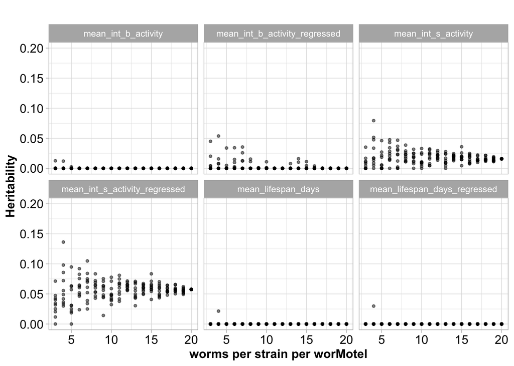

`mean_int_b_activity` = mean integrated base activity  
`mean_int_s_activity` = mean integrated stimulated activity  
`mean_lifespan_days = mean lifespan days`

## Sampled two “good” blocks with three worMotels each

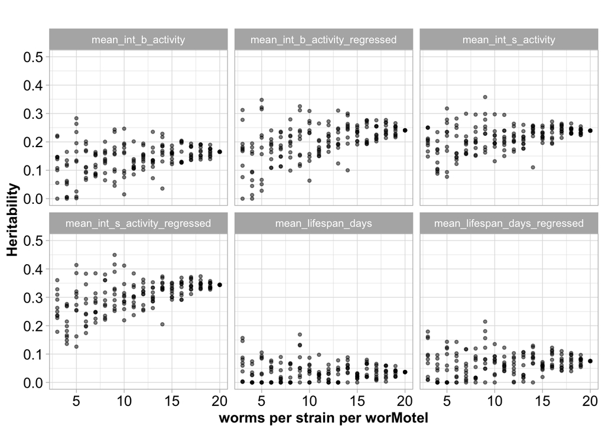

## Sample two “good” blocks with one worMotel each

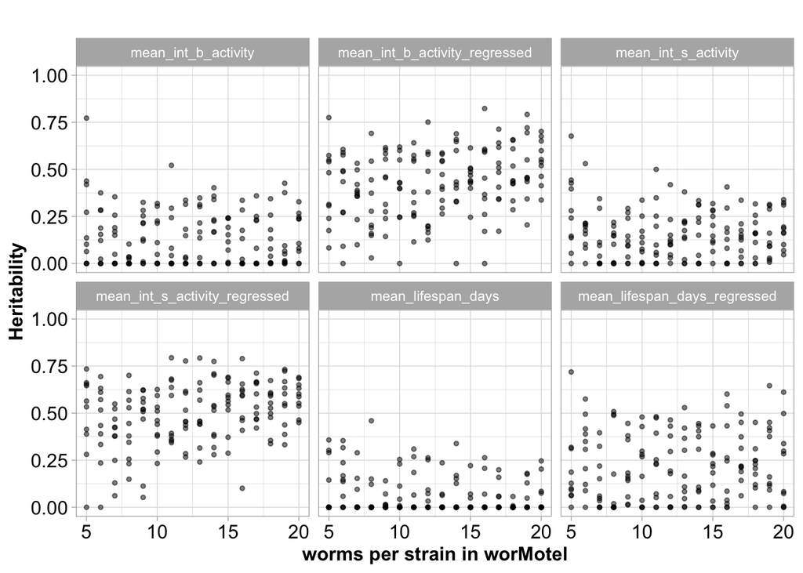

Sampled a single worm motel from blocks 3 and 4. The sampled worMotel had 5-20 worms per strain. H2 calculated from the two block means.

## Sample four blocks with one worMotel each

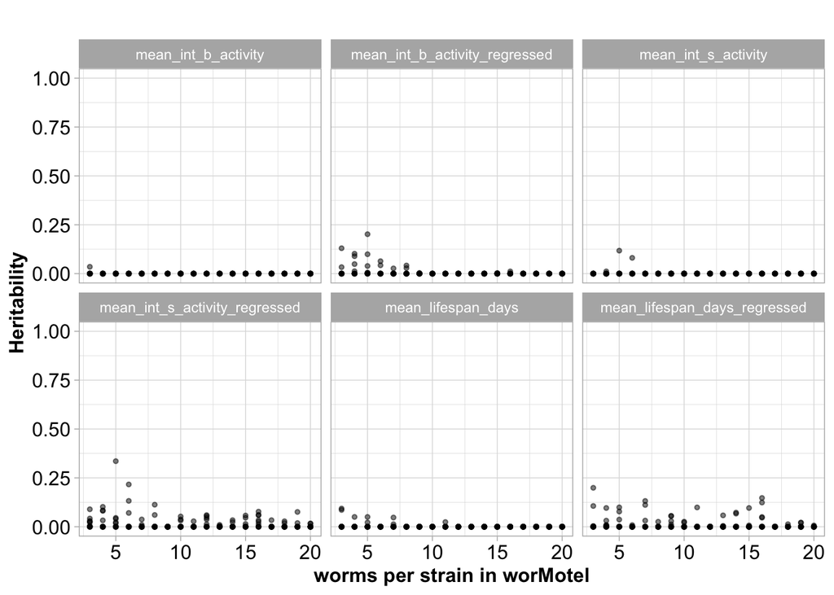

Sampled a single worm motel from all blocks. The sampled worMotel had 3-20 worms per strain. H2 calculated from the block means.